# Chapter 16: Dates and times

```r
library(tidyverse)
library(lubridate)
library(nycflights13)
```

# 16.2 Creating date/times

```r
make_datetime_100 <- function(year, month, day, time) {
  make_datetime(year, month, day, time %/% 100, time %% 100)
}
flights_dt <- flights %>%
  filter(!is.na(dep_time), !is.na(arr_time)) %>%
  mutate(
    dep_time = make_datetime_100(year, month, day, dep_time),
    arr_time = make_datetime_100(year, month, day, arr_time),
    sched_dep_time = make_datetime_100(year, month, day, sched_dep_time),
    sched_arr_time = make_datetime_100(year, month, day, sched_arr_time)
  ) %>%
  select(origin, dest, ends_with("delay"), ends_with("time"))
```

## 16.2.4 Exercises

1. What happens if you parse a string that contains invalid dates?

```r
ymd(c("2010-10-10", "bananas"))
```

```
 1 failed to parse.
```

```
[1] "2010-10-10" NA
```

**It gives a warning and the value becomes `NA`.**

2. What does the `tzone` argument to `today()` do? Why is it important?

```r
today(tzone = "UTC")
```

```
[1] "2017-04-03"
```

**The date can be different across timezones at a give point in time, so this allows us to specify which timezone we want to return the current date for.**

3. Use the appropriate lubridate function to parse each of the following dates:

```r
d1 <- "January 1, 2010"
d2 <- "2015-Mar-07"
d3 <- "06-Jun-2017"
d4 <- c("August 19 (2015)", "July 1 (2015)")
d5 <- "12/30/14" # Dec 30, 2014
mdy(d1)
```

```
[1] "2010-01-01"
```

```r
ymd(d2)
```

```
[1] "2015-03-07"
```

```r
dmy(d3)
```

```
[1] "2017-06-06"
```

```r
mdy(d4)
```

```
[1] "2015-08-19" "2015-07-01"
```

```r
mdy(d5)
```

```
[1] "2014-12-30"
```

# 16.3 Date-time components

## 16.3.4 Exercises

1. How does the distribution of flight times within a day change over the course of the year?

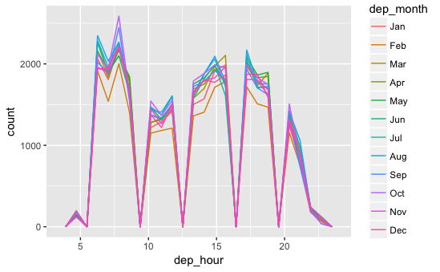

```r
flights_dt %>%
  mutate(
    dep_hour = hour(floor_date(sched_dep_time, unit = "hour")),
    dep_month = month(sched_dep_time, label = TRUE)
  ) %>%
  ggplot(aes(x = dep_hour, colour = dep_month)) +
    geom_freqpoly(bins = 24)
```

2. Compare `dep_time`, `sched_dep_time` and `dep_delay`. Are they consistent? Explain your findings.

```r
flights_dt %>%
  mutate(calc_dep_time = sched_dep_time + minutes(dep_delay)) %>%
  filter(dep_time != calc_dep_time)
```

| origin | dest | dep_delay | arr_delay | dep_time | sched_dep_time | arr_time | sched_arr_time | air_time | calc_dep_time |
| --- | --- | --- | --- | --- | --- | --- | --- | --- | --- |
| JFK | BWI | 853 | 851 | 2013-01-01 08:48:00 | 2013-01-01 18:35:00 | 2013-01-01 10:01:00 | 2013-01-01 19:50:00 | 41 | 2013-01-02 08:48:00 |
| JFK | SJU | 43 | 36 | 2013-01-02 00:42:00 | 2013-01-02 23:59:00 | 2013-01-02 05:18:00 | 2013-01-02 04:42:00 | 189 | 2013-01-03 00:42:00 |
| JFK | SYR | 156 | 154 | 2013-01-02 01:26:00 | 2013-01-02 22:50:00 | 2013-01-02 02:33:00 | 2013-01-02 23:59:00 | 49 | 2013-01-03 01:26:00 |
| JFK | SJU | 33 | 22 | 2013-01-03 00:32:00 | 2013-01-03 23:59:00 | 2013-01-03 05:04:00 | 2013-01-03 04:42:00 | 193 | 2013-01-04 00:32:00 |
| JFK | BUF | 185 | 172 | 2013-01-03 00:50:00 | 2013-01-03 21:45:00 | 2013-01-03 02:03:00 | 2013-01-03 23:11:00 | 58 | 2013-01-04 00:50:00 |
| JFK | BQN | 156 | 143 | 2013-01-03 02:35:00 | 2013-01-03 23:59:00 | 2013-01-03 07:00:00 | 2013-01-03 04:37:00 | 186 | 2013-01-04 02:35:00 |
| JFK | SJU | 26 | 23 | 2013-01-04 00:25:00 | 2013-01-04 23:59:00 | 2013-01-04 05:05:00 | 2013-01-04 04:42:00 | 194 | 2013-01-05 00:25:00 |
| JFK | PWM | 141 | 125 | 2013-01-04 01:06:00 | 2013-01-04 22:45:00 | 2013-01-04 02:01:00 | 2013-01-04 23:56:00 | 44 | 2013-01-05 01:06:00 |
| JFK | PSE | 15 | 18 | 2013-01-05 00:14:00 | 2013-01-05 23:59:00 | 2013-01-05 05:03:00 | 2013-01-05 04:45:00 | 201 | 2013-01-06 00:14:00 |
| JFK | FLL | 127 | 130 | 2013-01-05 00:37:00 | 2013-01-05 22:30:00 | 2013-01-05 03:41:00 | 2013-01-05 01:31:00 | 163 | 2013-01-06 00:37:00 |

[output cut: 990 more lines]

**A small proportion of the flights have a mismatch between the recorded departure delay and the delay reflected by the scheduled and actual departure times. These flights all appear to have recorded departure times that are ahead of the scheduled departure time and many are around late night / early morning times. As noted during the chapter 5 exercises there were flights that were delayed onto the next day, and the creation of these datetime variables didn’t take that into account - the departure date is wrong and hence the calculation of delay doesn’t match up.**

3. Compare `air_time` with the duration between the departure and arrival. Explain your findings. (Hint: consider the location of the airport.)

```r
flights_dt%>%
  mutate(
    duration = arr_time - dep_time
  ) %>%
  filter(duration == air_time)
```

| origin | dest | dep_delay | arr_delay | dep_time | sched_dep_time | arr_time | sched_arr_time | air_time | duration |
| --- | --- | --- | --- | --- | --- | --- | --- | --- | --- |
| LGA | BNA | -10 | 11 | 2013-01-07 11:50:00 | 2013-01-07 12:00:00 | 2013-01-07 13:41:00 | 2013-01-07 13:30:00 | 111 | 111 mins |
| EWR | MSP | 92 | 106 | 2013-01-13 19:47:00 | 2013-01-13 18:15:00 | 2013-01-13 22:18:00 | 2013-01-13 20:32:00 | 151 | 151 mins |
| LGA | MDW | 51 | 104 | 2013-01-16 06:51:00 | 2013-01-16 06:00:00 | 2013-01-16 09:14:00 | 2013-01-16 07:30:00 | 143 | 143 mins |
| EWR | HOU | 2 | 51 | 2013-01-16 07:07:00 | 2013-01-16 07:05:00 | 2013-01-16 11:06:00 | 2013-01-16 10:15:00 | 239 | 239 mins |
| LGA | BNA | -2 | 36 | 2013-01-16 09:43:00 | 2013-01-16 09:45:00 | 2013-01-16 12:11:00 | 2013-01-16 11:35:00 | 148 | 148 mins |
| LGA | BNA | -1 | 36 | 2013-01-25 16:19:00 | 2013-01-25 16:20:00 | 2013-01-25 18:26:00 | 2013-01-25 17:50:00 | 127 | 127 mins |
| EWR | ORD | 6 | 54 | 2013-01-30 10:16:00 | 2013-01-30 10:10:00 | 2013-01-30 12:34:00 | 2013-01-30 11:40:00 | 138 | 138 mins |
| EWR | ORD | -1 | 24 | 2013-01-30 14:19:00 | 2013-01-30 14:20:00 | 2013-01-30 16:14:00 | 2013-01-30 15:50:00 | 115 | 115 mins |
| EWR | ORD | 55 | 87 | 2013-01-30 21:55:00 | 2013-01-30 21:00:00 | 2013-01-30 23:47:00 | 2013-01-30 22:20:00 | 112 | 112 mins |
| LGA | ORD | 63 | 76 | 2013-10-02 18:53:00 | 2013-10-02 17:50:00 | 2013-10-02 20:45:00 | 2013-10-02 19:29:00 | 112 | 112 mins |

[output cut: 186 more lines]

**Very few of these match up. Timezones are at least part of the reason because the arrival times are expressed in local time for the destination, but as I noted in exercise 2 of section 5.5.2 I’m not sure that is the only factor involved..**

4. How does the average delay time change over the course of a day? Should you use `dep_time` or `sched_dep_time`? Why?

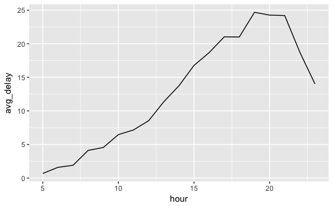

```r
flights_dt %>%
  mutate(hour = hour(sched_dep_time)) %>%
  group_by(hour) %>%
  summarise(avg_delay = mean(dep_delay, na.rm = TRUE)) %>%
  ggplot(aes(hour, avg_delay)) +
    geom_line()
```

5. On what day of the week should you leave if you want to minimise the chance of a delay?

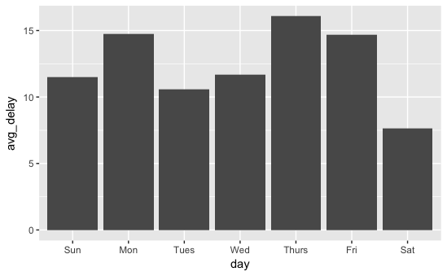

```r
flights_dt%>%
  mutate(day = wday(sched_dep_time, label = TRUE)) %>%
  group_by(day) %>%
  summarise(avg_delay = mean(dep_delay, na.rm = TRUE)) %>%
  ggplot(aes(day, avg_delay)) +
    geom_col()
```

6. What makes the distribution of `diamonds$carat` and `flights$sched_dep_time` similar?

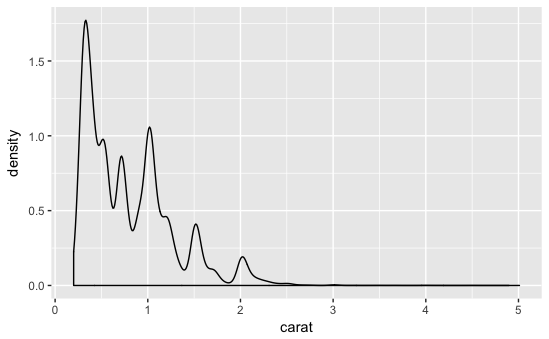

```r
ggplot(diamonds, aes(carat)) +
  geom_density()
```

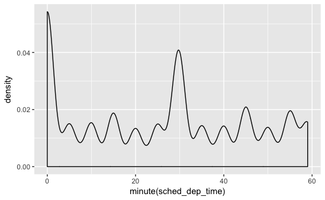

```r
flights_dt %>%
  ggplot(aes(minute(sched_dep_time))) +
    geom_density()
```

**They both have peaks and torughs that represent the tendency to record “nice” values - in the case of `diamonds` that involves whole numbers or easy fractions for carat values, and in `flights` it’s departure times on the hour, then at half past, quarter to/past, and then the 5/10 minutes intervals.**

7. Confirm my hypothesis that the early departures of flights in minutes 20-30 and 50-60 are caused by scheduled flights that leave early. Hint: create a binary variable that tells you whether or not a flight was delayed.

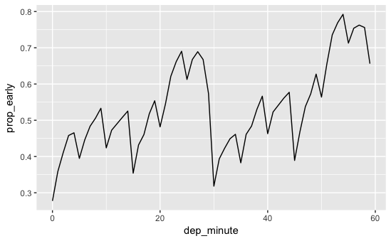

```r
flights_dt %>%
  mutate(
    early = dep_delay < 0,
    dep_minute = minute(dep_time)
  ) %>%
  group_by(dep_minute) %>%
  summarise(prop_early = mean(early)) %>%
  ggplot(aes(dep_minute, prop_early)) +
    geom_line()
```

```r
NA
```

# 16.4 Time spans

## 16.4.5 Exercises

1. Why is there `months()` but no `dmonths()`?

**Durations record the time span in seconds, but months vary in their length so they can’t be assigned a fixed value in seconds.**

2. Explain `days(overnight * 1)` to someone who has just started learning R. How does it work?

3. Create a vector of dates giving the first day of every month in 2015. Create a vector of dates giving the first day of every month in the current year.

```r
dmy("1/1/2015") + months(0:11)
```

```
 [1] "2015-01-01" "2015-02-01" "2015-03-01" "2015-04-01"
 [5] "2015-05-01" "2015-06-01" "2015-07-01" "2015-08-01"
 [9] "2015-09-01" "2015-10-01" "2015-11-01" "2015-12-01"
```

```r
update(today(), yday = 1) + months(0:11)
```

```
 [1] "2017-01-01" "2017-02-01" "2017-03-01" "2017-04-01"
 [5] "2017-05-01" "2017-06-01" "2017-07-01" "2017-08-01"
 [9] "2017-09-01" "2017-10-01" "2017-11-01" "2017-12-01"
```

4. Write a function that given your birthday (as a date), returns how old you are in years.

```r
age <- function(birthday) {
  (birthday %--% today()) %/% years(1)
}
age(dmy("25/6/1975"))
```

```
[1] 41
```

```r
age(dmy("23/2/2000"))
```

```
[1] 17
```

5. Why can’t `(today() %--% (today() + years(1)) / months(1)` work?

```r
(today() %--% (today() + years(1)) / months(1)
```

```
Error: Incomplete expression: (today() % (today() + years(1)) / months(1)
```

**There is a missing closing parenthesis, which I assume isn’t the purpose of the exercise. I’ll presume it’s supposed to close off the section prior to the division.**

```r
(today() %--% (today() + years(1))) / months(1)
```

```
[1] 12
```

**But that appears to work so I’m not sure what the issue is.**